# Your Digest for Friday, Oct 13, 2023 11:59 PM

# Plasmacytoma

#2020BSQ-JUL/Q28

> Plasmacytoma is a rare **plasma cell dyscrasia** that grows *within the axial skeleton or soft tissue structures* as solitary or multiple masses **without evidence of systemic disease**. It is an **early plasma cell malignancy** and is considered an *intermediate phase between monoclonal gammopathy of undetermined significance(MGUS) and multiple myeloma (MM)* [Source](https://www.ncbi.nlm.nih.gov/books/NBK573076/)

# Urethritis in males

- Inflammation of the urethra.
- Common manifestation of sexually transmitted diseases in males.
- It's also usually *caused* by sexually transmitted pathogens.
- Pathogens
  - Neisseria gonorrhoeae - easily visualized on gram stain.
    - Which has led to the clinical classification of Non gonococcal vs. Gonococcal urethritis.
    - They are gram -ve diplogocci.
    - Treat with single dose of **IM ceftriaxone**.
    - Frequently *coinfection with chlamydia* occurs. That is treated with *doxycycline*. (can start presumptively)
  - Non gonococcal urethritis:
    - Chlamydia trachomatis - *most common NGU pathogen*
    - Mycooplasma genitalium - *second most common*
    - Others (uncommon)
      - Trichomonas vaginalis
      - Treponema pallidum - endourethral syphilitic chancre
      - haemophilus influenzae

# Innate immune system

## Pattern recognition receptors

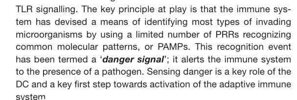

Innate system activation relies on a

- limited set of molecules on the pathogens called PAMPs (pathogen associated molecular patterns)
- Limited set of receptors on the host side called PRRs (pattern recognition receptors).
  - PRRs are present on macrophages and dendritic cells - used for '*pathogen sensing*'.
  - PRRs bind go molecules which are common to pathogens.
  - Examples
    - *Mannose binding lectin* is a PRR which also activates complement, promoting opsonization.i
    - **TLR**s are signalling PRRs.
      - Toll like receptor 4 (TLR4) - binds lps from bacterial capsules
      - Other TLRs bind viral components.

> [!INFO] The **dendritic cells** serve as a bridge between the innate and specific immune systems.

# Immune cytokines

> [!INFO] What are Cytokines?  
> Small *polypeptides* released by a cell to modify the function of other cells or it's own.  
> They key features of a cytokine
> 1. autocrine activity - acts on the same cell
> 2. paracrine activity - acts on nearby cells
> 3. endocrine activity - acts distantly
> 4. synergism with other cytokines
> 5. pleitropy - different actions on different cells.

#2020BSQ-JUL/Q25

- IM = Malaise, headache, fever progressing to *pharyngitis* with *cervical lymphadenopathy*.
- Lymphadenopathy: Symmetrical, **tender**, *posterior chain predominant*
- Pharyngitis / tonsilitis - *exudate may be present* (but it's not a bacterial infection!)
- Rash - made worse by penicillin, generalized maculopapular, urticarial, or petechial rash is occasionally seen
- Associated with *B , T , Hodgkin lymphoma*
- #splenomegaly is common; **Splenic rupture is a rare but life threatening** complication.
- *Airway obstruction* can occur.
- Diagnosis : *heterophile* antibody test or EBV serology

## Complications of EBV infection

#2020BSQ-JUL/Q28  
In addition to those listed above,

- Chronic active EBV infection - Persistent IM like syndrome with continued viraemia. It's a life threatening lymphoproliferative disorder.
- Associated
  - with multiple sclerosis,
  - *oral hairy leukoplakia* which is also associated with HIV (it is *NOT* a premalignant lesion)

[figure not shown]

  - Lymphoproliferative disorders
    - *Hemophagocytic lymphohistiocytosis*
    - Post-transplant lymphoproliferative disease
  - Malignancy - *proteins made by the virus cause DNA instability*
    - *T and B* cell lymphomas
    - **lymphomas** in *transplant recipients*
    - **Burkitt** lymphoma — Burkitt lymphoma (BL), which is characteristically *localized in the jaw*
    - In HIV patients, EBV is associated with
      - **Non-Hodgkin lymphoma**
      - Smooth muscle tumours in children
    - *Hodgkin lymphoma*
    - *Nasopharyngeal* carcinoma
    - **Gastric** carcinoma
    - **T cell lymphoma**
    - *no association has been show between EBV and kaposi sarcoma* (UpToDate)

# Kaposi sarcoma

- Kaposi sarcoma (KS) is an **angioproliferative** disorder that requires infection with human herpesvirus 8 (*HHV-8*), also known as Kaposi sarcoma-associated herpesvirus (KSHV), for its development.
- HHV-8 genome contain viral oncogenes
- > These same genes may cause the endothelial cells to form new blood vessels and may also increase the production of certain chemicals that cause inflammation
- Most infections with KSHV are asymptomatic. But Immunosuppresion is a risk factor for Kaposir sarcoma development.
- KSHV is also found in saliva, semen, and vaginal fluid [Source](https://www.cancer.org/cancer/types/kaposi-sarcoma/causes-risks-prevention/what-causes.html)

#2020BSQ-JUL/Q38  
Initially, incorrectly, thought to be a myelopathy.

- CMT-1: **Pain and temperature are usually not affected** because they are carried by *unmyelinated "C-Fibers".*
- An unstable type of myelin is formed and repeated myelination and demyelination lead to **thickened nerves.**
- CMT-2
- CMT-3: severe, infantile form
- CMT-4:
- Onset usually in *first two decades of life*.
- **Lower limbs more involved** than upper limbs; *frequent tripping and sprained ankles*; *steppage gait* due to **foot drop**.
- Intrinsic foot muscle weakness can cause *pes cavus.* Muscle wasting -> stork leg or *inverted champagne bottle appearance.*
- Upper limb involvement causes *difficulty handling small objects like zippers and buttons*.
- There is sensory loss (numbness) as well (although patients may not recognize it because it is chronic)
- Disease progression appears to *accelerate after age of 50 years*.
- Usual laboratory rests are all normal; EMG and high resolution ultrasound may help diagnosis.
- Slowly progressive disease; lifespan not affected but disability from peripheral muscle weakness will occur. Deformity may need surgical correction. No curative medical therapies exist.

# Refsum disease

#2020BSQ-JUL/Q38

> Clinical symptoms may develop from infancy to adulthood and include progressive retinitis pigmentosa, *peripheral polyneuropathy*, *cerebellar ataxia*, *sensorineural deafness*, ichthyosis, *anosmia*, and cardiac conduction defects.

#2020BSQ-JUL/Q27

# Tay Sach's disease

#2020BSQ-JUL/Q29  
A #autosomal-Recessive defect in hexosaminidase which causes accumulation of lipids within cells. Particularly affects CNS neurons. Affected *children* develop normally until about 6 months of age and then show cognitive decline with loss of milestones, dementia, blindness and *chery red spots* in the eyes.  
There is no treatment.

[output not shown]

#2020BSQ-JUL/Q25  
Pathogenesis: Autoimmune disease affecting **exocrine glands**.  
4. **Lungs** - interstitial lung disease; upper and small airway involvement; Patients have *cough* and dyspnoea.  
5. *Peripheral neuropathy*  
10. Can cause renal involvement - hypokalemia is common secondary to *distal renal tubular acidosis* [[2021-SBR-November#Renal tubular acidosis]] with K+ wasting.  
11. Rare complication of Sjogren syndrome during pregnancy : **congenital heart block.**

# Neutrophil defects

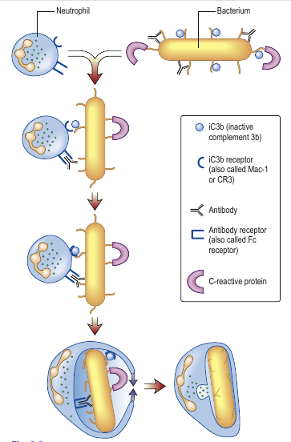

> [!INFO] presentation  
> > Is with *recurrent and severe* **bacterial** *(Staphylococcus, pseudomonas, salmonella, Nocardia)* and **fungal** *(candida, Aspergillus)* infections, most commonly of the respriatory tract and skin.

#2020BSQ-JUL/Q29

1. [[2022 May Basic Sciences#Chronic granulomatous disease|Chronic Granulomatous disease]] <- a defect in neutrophil killing.
2. **Leukocyte adhesion deficiency** -> a defect in 'firm' adhesion of leukocytes to vessel walls caused by defect in **integrins**. #autosomal-Recessive
   - Presents in early life with delayed umbilical cord separation, failure to lose primary dentition, severe gingivitis. There is **neutrophilia** but the cells *cannot reach sites of infection*. Recurrent infections in the first decade of life. Treatment is stem cell transplant.
3. Hyper IgE syndrome - Job's syndrome
   - #autosomalDominant
   - abnormal T cell function, increased IgE production and intermittent defects in neutrophil chemotaxis.
   - Dermatitis, boils, pneumonia
4. Schwachman-Diamond syndrome
   - Mild neutropenia + defect in neutrophil migration.
   - Resembles *cystic fibrosis clinically* with exocrine pancreatic failure + pyogenic infections.
5. Chediak-Higashi syndrome
   - Defective *phagolysosom fusion*. (large lysosome vesicles are seen within the neutrophils)
   - Recurrent infections, anaemia, hepatomegaly.
   - One cause of primary haemophagocytic lymphohistiocytosis.

## Acquired neutrophil defects / neutropenia

> AL amyloidosis must be differentiated from other forms of amyloidosis (eg, AA amyloidosis, ATTRmt amyloidosis, and ATTRwt amyloidosis) since the *latter are non-neoplastic and will not benefit from chemotherapy.*

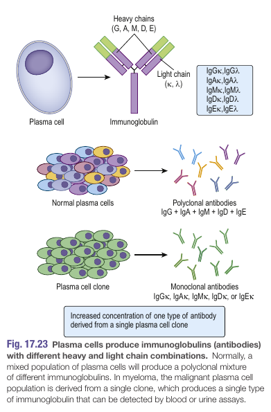

1. Small clone of premalignant cells produces M protein with no symptoms => **MGUS** / or ?*MGCS* (see below)  
3. Malignant:  
1.[[Haematologic malignancies-Summary#Multiple myeloma|Multiple Myeloma]]

> Most premalignant disorders in medicine have limited clinical consequence until malignant transformation occurs. In contrast, premalignant clonal expansion of plasma cells can result in disabling or fatal disease related to the secreted immunoglobulin, termed *monoclonal gammopathy of clinical significance*. When there are paraproteins but no clinical effect, it's called *monoclonal gammopathy of **unknown** signfinicance*

When a disease which causes paraproteinemia occurs, the resultant symptoms can be caused by either the paraproteins or the disease process itself. (eg. Myeloma will cause hypercalcemia due to lytic lesions but also symptoms due to paraproteinaemias).  
Clinical *manifestations of **paraproteinemias***

- agglutination of RBCs - *Cold agglutinin disease*
- Insolubility in low temperatures - *Cryoglobulinemia*  
  [[2022 General Medicine Paper-May#Cryogobulinaemia]]
- Kidney impairment - seen in myeloma kidney

## POEMS syndrome

> [!INFO] Monoclonal gammopathies of clinical significance  
> There are some conditions where the clonal population is small and (?not yet) significantly malignant but still causes some clinical effect.

Therefore, POEMS is a *paraproteinaemic neuropathy*.  
P - demyelinating polyneuropathy.  
O - organomegaly  
E - endocrynopathy (reduced testosterone)  
M - **M** paraprotein band.  
S - Skin changes

> [!INFO] paraproteinaemic neuropathies  
> Presents as a length dependent, axonal, sensorimotor neuropathy. Mild distal weakness and loss of some or all sensory modalities. Peripheral neuropathy may precede the diagnosis of the underlying condition by years. [Source](https://www.ncbi.nlm.nih.gov/pmc/articles/PMC4731930/)
- POEMS is probably caused by VEGF secreted by the plasmacytoma.
- IgM paraproteins can also cause neuropathy - (anti-MAG)